# Species metadata description

# Biodiversity mapping

The following pdf gives a description of the data used in the pipeline run that corresponds to the folder this document resides in. It should be used as a guide for anyone who wants to know more about the data used in the corresponding outputs (maps and datasets) and/or would like to replicate the data.

We begin with basic information about the pipeline run.

| Characteristic | Value |
| --- | --- |
| Date | 2024-01-09 |
| Taxa | stoneflies, flies |
| Region type | county |
| Region code | 50 |
| Total species | 2784 |
| Total datasets used | 14 |
| DOI | 10.15468/dl.thj4uy |

In addition to the above, data was downloaded with a maximum uncertainty regarding coordinates of 100 metres.

The following shows total number of species per taxa and per dataset from the initial download from GBIF and ANO. Note that only the top 10 datasets are shown. A full list of observations per dataset per taxa as well as observations per species can be found in the appendices.

| taxa | species | redListedSpecies |
| --- | --- | --- |
| flies | 2739 | 3 |
| stoneflies | 45 | 0 |

| dsName | dataType | observations | redListedObservations |
| --- | --- | --- | --- |
| Freshwater benthic invertebrates ecological collection NTNU University Museum | PA | 3048468 | 0 |
| National insect monitoring in Norway | Counts | 28670 | 55 |
| Terrestrial and limnic invertebrates systematic collection, NTNU University Museum | PO | 26835 | 0 |
| Freshwater pelagic invertebrates ecological collection NTNU University Museum | PA | 10865 | 0 |
| Norwegian Species Observation Service | PO | 6650 | 6 |
| NINA insect database | PO | 252 | 0 |
| Entomology, Oslo (O) UiO | PO | 238 | 0 |
| NORSC - Sciaroidea, UiT Tromsø Museum | PO | 130 | 0 |
| iNaturalist Research-grade Observations | PO | 53 | 0 |
| Observation.org, Nature data from around the World | PO | 22 | 0 |

The following gives species richness for observations across the surveyed region by taxa.

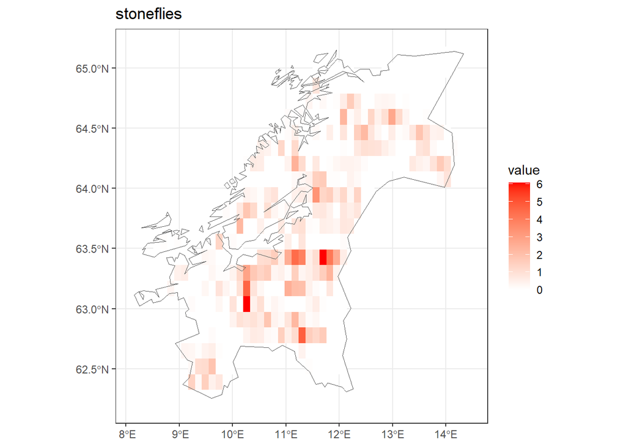

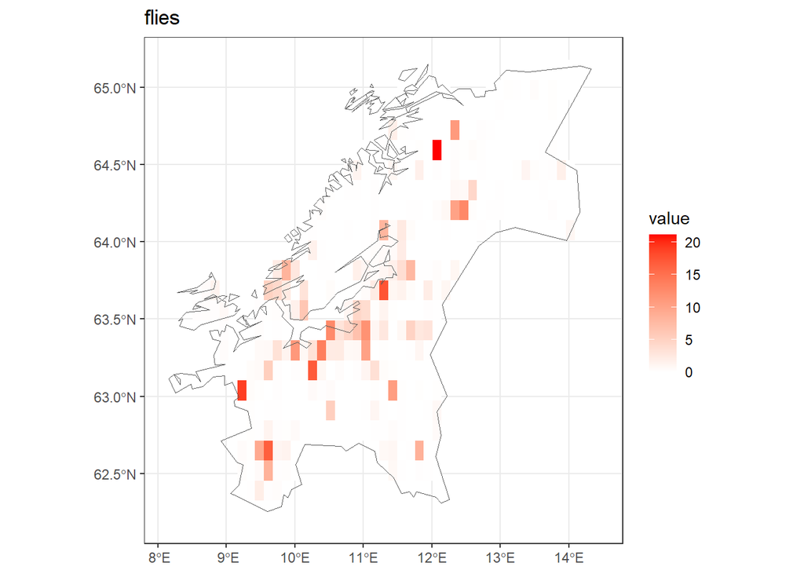

The following gives spatial density for observations across the surveyed region by taxa.

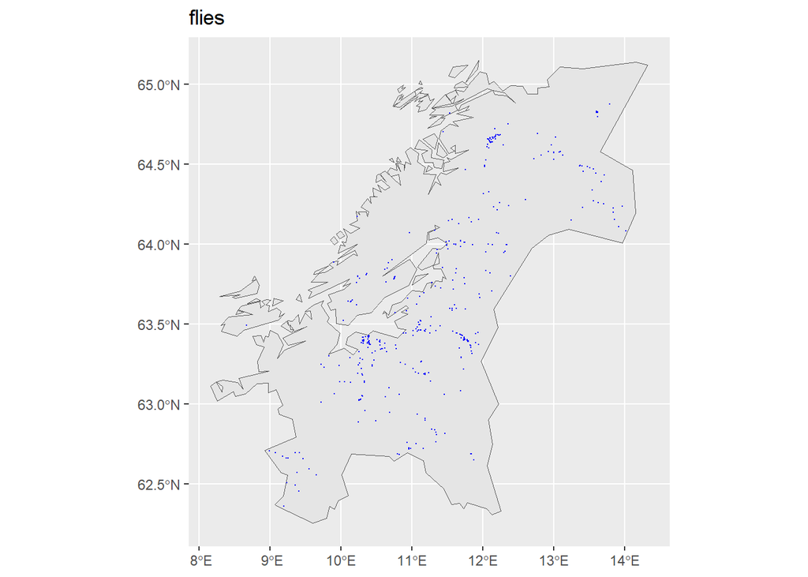

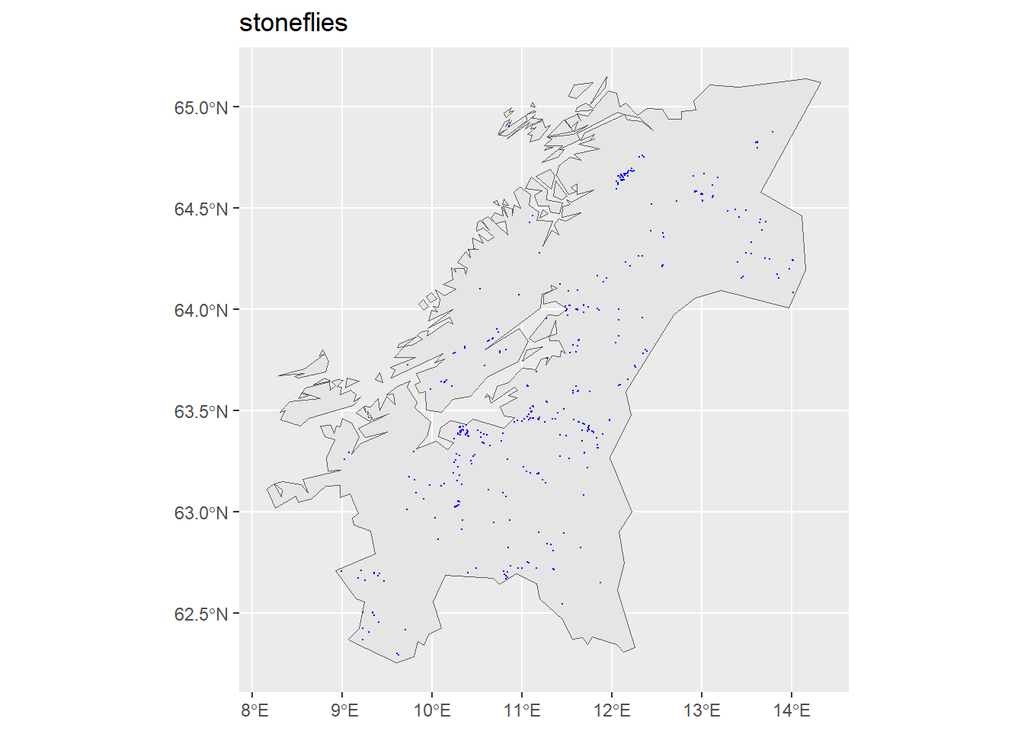

## Appendices

### Appendix 1

The tables below give further information on the observations used for our pipeline run.

Total numbers of observations used in pipeline run for each dataset by taxa.

| taxa | dsName | Observations |
| --- | --- | --- |
| flies | Freshwater benthic invertebrates ecological collection NTNU University Museum | 2412429 |
| flies | National insect monitoring in Norway | 28434 |
| flies | Terrestrial and limnic invertebrates systematic collection, NTNU University Museum | 24259 |
| flies | Freshwater pelagic invertebrates ecological collection NTNU University Museum | 10865 |
| flies | Norwegian Species Observation Service | 6561 |
| flies | NINA insect database | 252 |
| flies | Entomology, Oslo (O) UiO | 234 |
| flies | NORSC - Sciaroidea, UiT Tromsø Museum | 130 |
| flies | iNaturalist Research-grade Observations | 53 |
| flies | Observation.org, Nature data from around the World | 22 |
| flies | Diptera collection, Natural History Museum, University of Oslo | 17 |
| flies | Entomological collections, UiB | 11 |
| flies | Artportalen (Swedish Species Observation System) | 5 |
| flies | naturgucker | 1 |
| stoneflies | Freshwater benthic invertebrates ecological collection NTNU University Museum | 636039 |
| stoneflies | Terrestrial and limnic invertebrates systematic collection, NTNU University Museum | 2576 |
| stoneflies | National insect monitoring in Norway | 236 |
| stoneflies | Norwegian Species Observation Service | 89 |
| stoneflies | Artportalen (Swedish Species Observation System) | 15 |
| stoneflies | Entomology, Oslo (O) UiO | 4 |

Total numbers of observations used in pipeline run for each data type by taxa.

| taxa | dataType | Observations |
| --- | --- | --- |
| flies | PA | 2423294 |
| flies | PO | 31545 |
| flies | Counts | 28434 |
| stoneflies | PA | 636039 |
| stoneflies | PO | 2684 |
| stoneflies | Counts | 236 |